# 615 Project

10/19/2019

## Read the “World Value” data

Clean Data {.smaller}

Delete columns which has replicated values(non-information):

[output not shown]

[output cut: 57 more lines]

[output not shown]

## Clean data: Convert selected survey questions from character to numeric:

```
## # A tibble: 6 x 11
##   `V4: Important … `V5: Important … `V6: Important … `V7: Important …
##              <dbl>            <dbl>            <dbl>            <dbl>
## 1                5                4                5                4
## 2                5                5                4                3
## 3                5                3                5                3
## 4                5                4                4                4
## 5                5                5                5                4
## 6                5                5                4                5
## # … with 7 more variables: `V8: Important in life: Work` <dbl>, `V9:
## #   Important in life: Religion` <dbl>, `V10: Feeling of happiness` <dbl>,
## #   `V11: State of health (subjective)` <dbl>, `V60: Aims of country:
## #   first choice` <dbl>, `V62: Aims of respondent: first choice` <dbl>,
## #   `V64: Most important: first choice` <dbl>
```

## Preparation for factor analysis

Calculate correlations between selected survey questions:

```
##                                     V4: Important in life: Family
## V4: Important in life: Family                                1.00
## V5: Important in life: Friends                               0.38
## V6: Important in life: Leisure time                          0.20
## V7: Important in life: Politics                              0.19
## V8: Important in life: Work                                  0.19
## V9: Important in life: Religion                              0.32
##                                     V5: Important in life: Friends
## V4: Important in life: Family                                 0.38
## V5: Important in life: Friends                                1.00
## V6: Important in life: Leisure time                           0.33
## V7: Important in life: Politics                               0.21
## V8: Important in life: Work                                   0.08
## V9: Important in life: Religion                               0.18
##                                     V6: Important in life: Leisure time
## V4: Important in life: Family                                      0.20
## V5: Important in life: Friends                                     0.33
## V6: Important in life: Leisure time                                1.00
## V7: Important in life: Politics                                    0.21
## V8: Important in life: Work                                        0.18
## V9: Important in life: Religion                                    0.05
##                                     V7: Important in life: Politics
## V4: Important in life: Family                                  0.19
## V5: Important in life: Friends                                 0.21
## V6: Important in life: Leisure time                            0.21
## V7: Important in life: Politics                                1.00
## V8: Important in life: Work                                    0.19
## V9: Important in life: Religion                                0.19
##                                     V8: Important in life: Work
## V4: Important in life: Family                              0.19
## V5: Important in life: Friends                             0.08
## V6: Important in life: Leisure time                        0.18
## V7: Important in life: Politics                            0.19
## V8: Important in life: Work                                1.00
## V9: Important in life: Religion                            0.16
##                                     V9: Important in life: Religion
## V4: Important in life: Family                                  0.32
## V5: Important in life: Friends                                 0.18
## V6: Important in life: Leisure time                            0.05
## V7: Important in life: Politics                                0.19
```

[output cut: 22 more lines]

```
## V9: Important in life: Religion                                  -0.07
##                                     V62: Aims of respondent: first choice
## V4: Important in life: Family                                       -0.05
## V5: Important in life: Friends                                      -0.01
## V6: Important in life: Leisure time                                 -0.10
## V7: Important in life: Politics                                      0.09
## V8: Important in life: Work                                         -0.03
## V9: Important in life: Religion                                     -0.05
##                                     V64: Most important: first choice
## V4: Important in life: Family                                   -0.08
## V5: Important in life: Friends                                  -0.09
## V6: Important in life: Leisure time                             -0.04
## V7: Important in life: Politics                                 -0.04
## V8: Important in life: Work                                      0.00
## V9: Important in life: Religion                                 -0.02
```

```
## R was not square, finding R from data
```

```
## $chisq
## [1] 2272.999
##
## $p.value
## [1] 0
##
## $df
## [1] 55
```

```
## [1] 0.3602762
```

From output data, Bartlett’s test is highly significant, assymptotically chisquare is 2273, and P-value of chi square smaller than 0.001, therefore factor analysis is appropriate.  
And since the determinant is 0.36 larger than 0.00001, so our determinant does not seem problematic.

Since my goal is reduce number of variables(selected survey questions) in my data by extracting important one from the data, thus, I will using PCA to do factor extraction.

## Factor extraction by using PCA:

Show scree Plot by using parallel analysis:

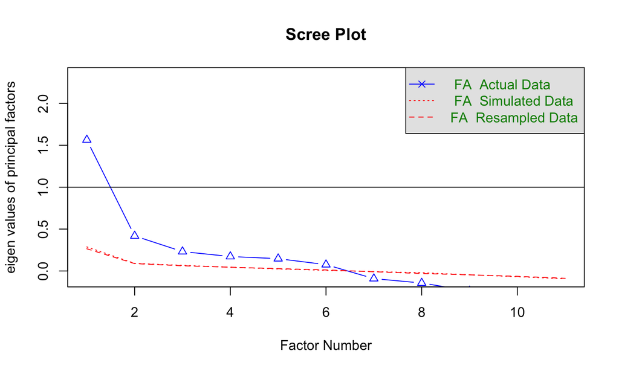

```
## Parallel analysis suggests that the number of factors =  6  and the number of components =  NA
```

From the parallel analysis, the plot shows from 2 to 6 will be great choice.

## Scree plot by using another way:

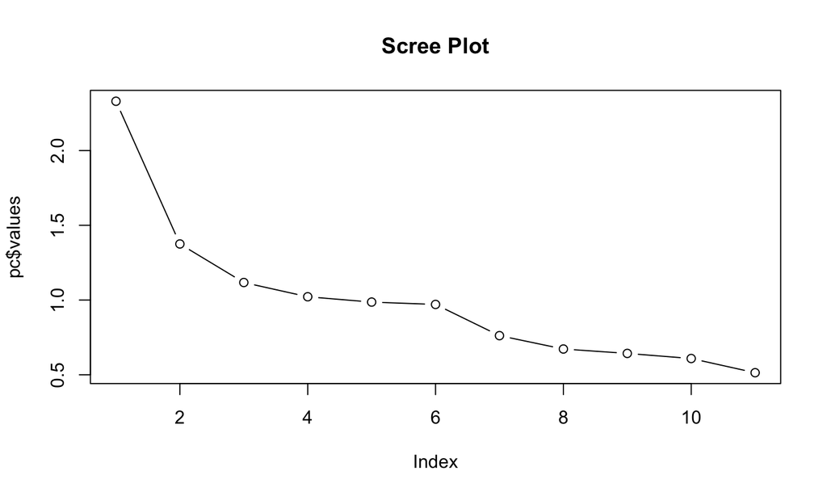

## Redo PCA by using 3 factors

```
## Principal Components Analysis
## Call: principal(r = newdata[x], nfactors = 3, rotate = "none")
## Standardized loadings (pattern matrix) based upon correlation matrix
##                                         PC1   PC2   PC3   h2   u2 com
## V4: Important in life: Family          0.68 -0.06  0.24 0.53 0.47 1.3
## V5: Important in life: Friends         0.64  0.00  0.08 0.42 0.58 1.0
## V6: Important in life: Leisure time    0.54  0.03 -0.08 0.30 0.70 1.1
## V7: Important in life: Politics        0.51  0.08  0.19 0.30 0.70 1.3
## V8: Important in life: Work            0.41  0.17  0.13 0.21 0.79 1.5
## V9: Important in life: Religion        0.49  0.02  0.37 0.37 0.63 1.9
## V10: Feeling of happiness              0.58  0.29 -0.38 0.57 0.43 2.3
## V11: State of health (subjective)      0.21  0.36 -0.76 0.74 0.26 1.6
## V60: Aims of country: first choice    -0.26  0.67  0.22 0.57 0.43 1.5
## V62: Aims of respondent: first choice -0.08  0.47 -0.01 0.23 0.77 1.1
## V64: Most important: first choice     -0.20  0.67  0.31 0.58 0.42 1.6
##
##                        PC1  PC2  PC3
## SS loadings           2.33 1.38 1.12
## Proportion Var        0.21 0.13 0.10
## Cumulative Var        0.21 0.34 0.44
## Proportion Explained  0.48 0.29 0.23
## Cumulative Proportion 0.48 0.77 1.00
##
## Mean item complexity =  1.5
## Test of the hypothesis that 3 components are sufficient.
##
## The root mean square of the residuals (RMSR) is  0.11
##  with the empirical chi square  2848.59  with prob <  0
##
## Fit based upon off diagonal values = 0.51
```

Through output data, Cumulative var shows these 3 principle components explains 44% data with 11 variables.

```
## [1] 0.5818182
```

Since all facto1, factor2 and factor3’s data are below 0.8 and over 0.3, which is encouraging.

## Orthogonal rotation(varimaax):

For easier to explain the output of factor extraction, we can using orthogonal rotation to decreasing noice for factors as much as possible.

```
## Principal Components Analysis
## Call: principal(r = newdata[x], nfactors = 3, rotate = "varimax")
## Standardized loadings (pattern matrix) based upon correlation matrix
##                                       item   RC1   RC2   RC3   h2   u2 com
## V4: Important in life: Family            1  0.71             0.53 0.47 1.1
## V5: Important in life: Friends           2  0.62             0.42 0.58 1.2
## V9: Important in life: Religion          6  0.59             0.37 0.63 1.1
## V7: Important in life: Politics          4  0.55             0.30 0.70 1.0
## V6: Important in life: Leisure time      3  0.46             0.30 0.70 1.8
## V8: Important in life: Work              5  0.44             0.21 0.79 1.2
## V64: Most important: first choice       11        0.76       0.58 0.42 1.0
## V60: Aims of country: first choice       9        0.75       0.57 0.43 1.0
## V62: Aims of respondent: first choice   10        0.45       0.23 0.77 1.2
## V11: State of health (subjective)        8              0.86 0.74 0.26 1.0
## V10: Feeling of happiness                7  0.40        0.64 0.57 0.43 1.7
##
##                        RC1  RC2  RC3
## SS loadings           2.12 1.40 1.30
## Proportion Var        0.19 0.13 0.12
## Cumulative Var        0.19 0.32 0.44
## Proportion Explained  0.44 0.29 0.27
## Cumulative Proportion 0.44 0.73 1.00
##
## Mean item complexity =  1.2
## Test of the hypothesis that 3 components are sufficient.
##
## The root mean square of the residuals (RMSR) is  0.11
##  with the empirical chi square  2848.59  with prob <  0
##  table after orthogonal rotation
## Fit based upon off diagonal values = 0.51
```

## Obersevation:

According to the results and the questionnaires, We can find the questions that load highly on factor 1 are V4(“Important in life:Family”) with the highest loading of 0.71, and lowest loading of 0.4 is V10(Feeling of happiness). Factor 2 are mianly explained by V64(Most important:first choice) and V60(Aim of country:first choice) with loading of 0.76 and 0.75. Factor 3 are mainly explained by V11(state of health) with 0.86 and the loweest loading of 0.64 is V10(Feeling of happiness).

Conclusion: Based on the obsersation, we can summarize the factor 1 as hapiness people consider a lot are important in life and label factor 2 as the expectation from people to country, factor 3 as causes of healthy people

## Ploting PCA

Relationship between varaibles and our components:

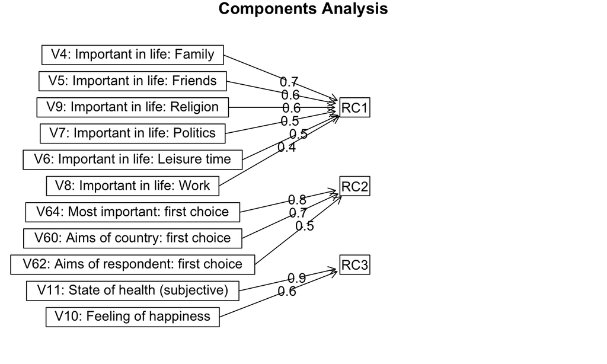

## Ploting PCA

Relationship between compononet 1 vs 2: kind of linearity.

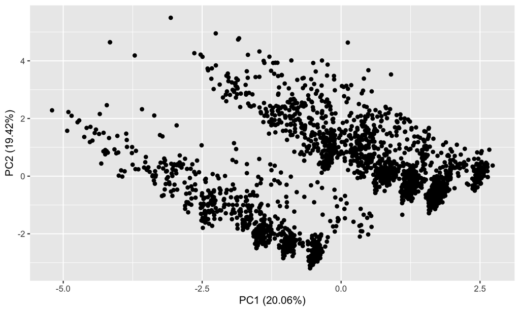

## Ploting PCA

Relationship between component by using cluster:

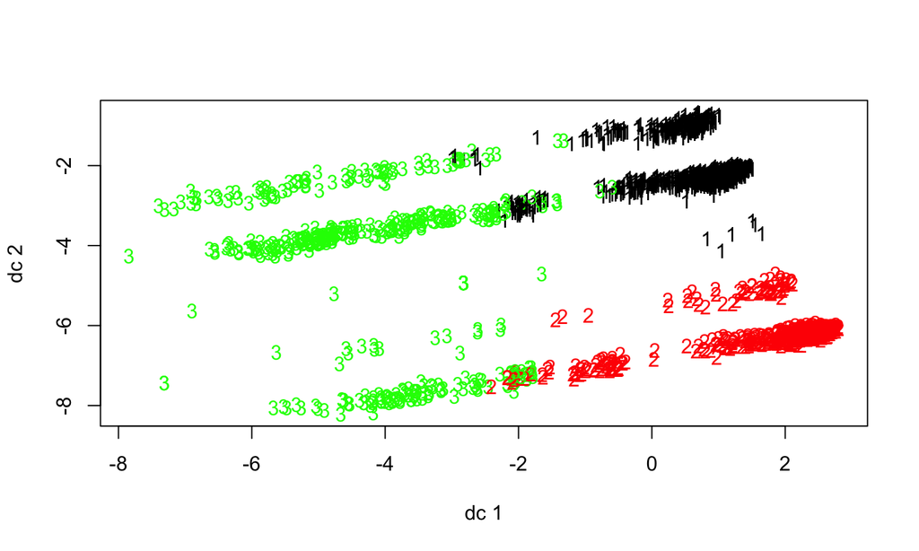

## Ploting PCA

Relationship between component by using cluster:

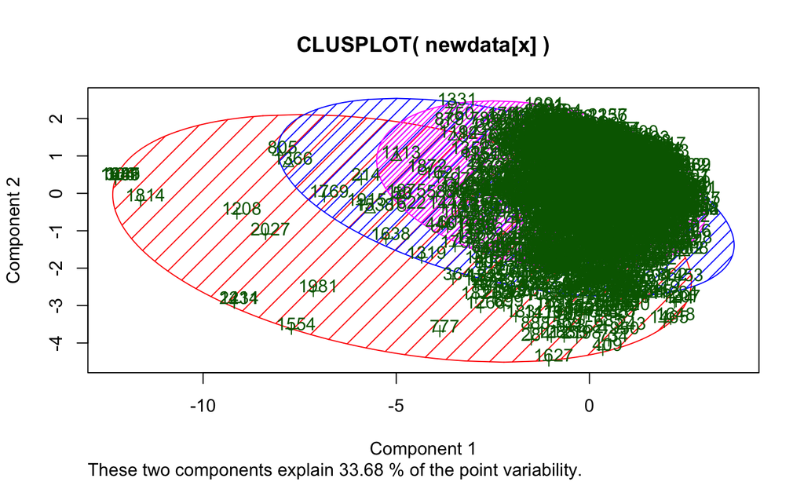